# Exploring Cohon Calibration

Kris Esturas

2026-03-02

# 1. Introduction

Boundary penalties are used in spatial conservation planning to reduce fragmentation. In *prioritizr*, `add_boundary_penalties()` encourages solutions to form **compact clusters** of planning units rather than **scattered** selections. Compact solutions are often easier to manage and may better support ecological processes, but they usually come at a higher cost.

A common challenge is that the boundary penalty is often set **arbitrarily**. If the penalty is too small, solutions remain fragmented. If it is too large, solutions become overly compact and can become very expensive. This makes it hard to judge whether the implied trade-off between cost and compactness is reasonable.

The function `calibrate_cohon_penalty()` in *prioritizr* provides a more systematic approach. It applies **Cohon-style calibration** to estimate a boundary penalty that aims to balance cost and compactness, using two extreme solutions (see Section 2: A brief note on Cohon-style calibration).

In this vignette, we use the Tasmania example dataset to explore how this calibration behaves under simple, controlled changes to the problem. Specifically, we ask:

1. How does the calibrated boundary penalty change as we *change the conservation target*?
2. Do target–penalty patterns stay similar when feature complexity is reduced (and when changes are applied in reverse order)?
3. How does the calibrated boundary penalty change as we *change the number of features*?
4. Is the feature–penalty relationship consistent across different feature compositions (and in reverse order)?
5. What are the *runtime implications* of Cohon-style calibration?

The goal is not to find a single “correct” penalty. Instead, we aim to understand how sensitive the calibration is to problem structure, and what that means for decision-support tools such as **spatialplanr** and **shinyplanr**.

# 2. A brief note on Cohon-style calibration

Very briefly, `calibrate_cohon_penalty()`:

1. Solves an “**ignore boundary**” problem (penalty ≈ 0) to find a very cheap but fragmented solution.
2. Solves a “**boundary-only**” problem (very large penalty) to find a very compact but otherwise expensive solution.
3. Uses these two “anchor” solutions (costs and boundary lengths) to compute a **boundary penalty** that trades off cost and boundary length in a more balanced way.
4. Returns this penalty so we can re-solve the problem with a **single calibrated value.**

The calibrated penalty therefore depends on how fragmented the cheap solution is and how expensive the compact solution needs to be. We therefore explore how changing targets and reducing the number of features affects the calibrated penalty.

# 3. Data and baseline set-up

We use the Tasmania planning unit and feature data from *prioritizrdata*. These data represent a realistic spatial conservation planning problem and are used in other *prioritizr* examples. To keep the vignette reasonably fast, we crop the study area to a smaller subregion.

## 3.1 Load and prepare the Tasmania data

The code below prepares the planning units and features for analysis.

```r
# Get planning units
tas_pu <- get_tas_pu() %>%
  dplyr::mutate(cost = cost)

# Convert features to sf
tas_features <- get_tas_features() %>%
  stars::st_as_stars() %>%
  sf::st_as_sf()

# Interpolate features to planning units
tas <- sf::st_interpolate_aw(
  tas_features,
  tas_pu,
  extensive = FALSE,
  keep_NA   = FALSE,
  na.rm     = FALSE
) %>%
  sf::st_join(tas_pu, join = sf::st_equals)
# List feature columns
all_features <- tas %>%
  sf::st_drop_geometry() %>%
  dplyr::select(-dplyr::all_of(c("id", "cost", "locked_in", "locked_out"))) %>%
  names()

# Binarise features
tas <- tas %>%
  dplyr::mutate(
    dplyr::across(dplyr::all_of(all_features), ~ dplyr::if_else(.x > 0, 1, 0))
  )

# Crop region
bbox <- tas %>%
  sf::st_bbox()

frac <- 0.50

bbox_small <- bbox
bbox_small["xmax"] <- bbox["xmin"] + frac * (bbox["xmax"] - bbox["xmin"])
bbox_small["ymax"] <- bbox["ymin"] + frac * (bbox["ymax"] - bbox["ymin"])

tas <- tas %>%
  sf::st_crop(bbox_small)
# Remove zero-only features
feature_totals <- tas %>%
  sf::st_drop_geometry() %>%
  dplyr::select(dplyr::all_of(all_features)) %>%
  dplyr::summarise(dplyr::across(dplyr::everything(), ~ sum(.x, na.rm = TRUE)))

zero_features <- feature_totals %>%
  dplyr::select(dplyr::where(~ .x == 0)) %>%
  names()

tas <- tas %>%
  dplyr::select(-dplyr::all_of(zero_features))

all_features <- setdiff(all_features, zero_features)
```

We then visualise the planning units.

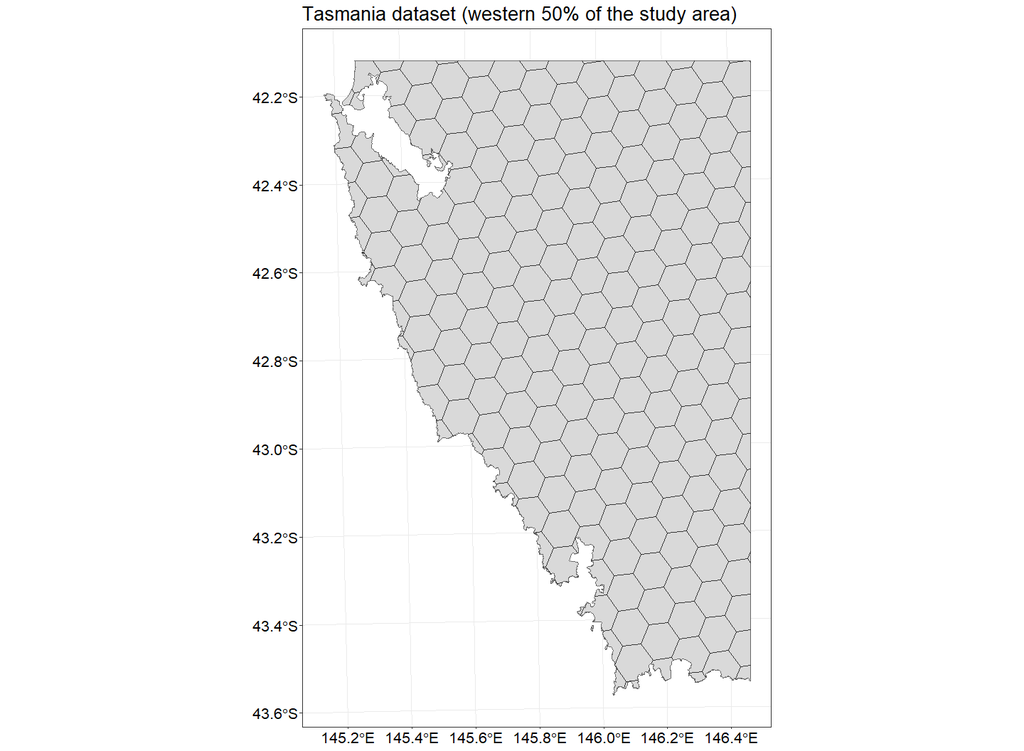

# 4. Helper functions

To keep the analysis readable, we create helper functions to summarise solution characteristics and standardise how problems are built, calibrated, and solved across scenarios.

## 4.1 Fragmentation and cost metrics

Each solution is summarised using a small set of interpretable metrics, including selected area, patch structure, boundary length, cost, and solver runtime.

```r
summarise_solution <- function(label,
                               solution_sf,
                               solve_time_sec,
                               min_patch_size   = NULL,
                               boundary_penalty = 0) {

  # Check inputs
  if (!"solution_1" %in% names(solution_sf)) {
    stop("summarise_solution(): column 'solution_1' not found in solution_sf")
  }
  if (!"cost" %in% names(solution_sf)) {
    stop("summarise_solution(): column 'cost' not found in solution_sf")
  }

  # Select PUs
  sel <- solution_sf %>%
    dplyr::filter(.data$solution_1 == 1)

  n_selected <- sel %>%
    nrow()

  # Return empty summary
  if (n_selected == 0) {
    return(
      tibble::tibble(
        method             = label,
        n_selected         = 0L,
        total_area_km2     = 0,
        n_patches          = 0L,
        valid_patches      = NA_integer_,
        median_patch_km2   = NA_real_,
        pu_cost_total      = 0,
        pu_cost_mean       = NA_real_,
        boundary_length_km = 0,
        boundary_cost      = 0,
        total_cost         = 0,
        solver_time_sec    = solve_time_sec
      )
    )
  }

  # Compute area
  pu_areas_m2 <- sel %>%
    sf::st_area() %>%
    as.numeric()

  total_area_km2 <- pu_areas_m2 %>%
    sum() %>%
    `/`(1e6)

  # Build patches
  patches <- sel %>%
    sf::st_union() %>%
    sf::st_cast("POLYGON")

  patch_areas_m2 <- patches %>%
    sf::st_area() %>%
    as.numeric()

  n_patches <- patch_areas_m2 %>%
    length()

  median_patch_km2 <- patch_areas_m2 %>%
    stats::median() %>%
    `/`(1e6)

  # Count valid patches
  valid_patches <- if (!is.null(min_patch_size)) {
    min_patch_size_m2 <- min_patch_size %>%
      as.numeric()
    patch_areas_m2 %>%
      `>=`(min_patch_size_m2) %>%
      sum()
  } else {
    NA_integer_
  }

  # Measure boundary
  boundary_length_km <- patches %>%
    sf::st_boundary() %>%
    sf::st_cast("MULTILINESTRING") %>%
    sf::st_length() %>%
    as.numeric() %>%
    sum() %>%
    `/`(1000)

  # Summarise costs
  pu_cost_total <- sel %>%
    dplyr::pull(.data$cost) %>%
    sum(na.rm = TRUE)

  pu_cost_mean <- sel %>%
    dplyr::pull(.data$cost) %>%
    mean(na.rm = TRUE)

  boundary_cost <- boundary_length_km * boundary_penalty
  total_cost    <- pu_cost_total + boundary_cost

  # Return summary
  tibble::tibble(
    method             = label,
    n_selected         = n_selected,
    total_area_km2     = total_area_km2,
    n_patches          = n_patches,
    valid_patches      = valid_patches,
    median_patch_km2   = median_patch_km2,
    pu_cost_total      = pu_cost_total,
    pu_cost_mean       = pu_cost_mean,
    boundary_length_km = boundary_length_km,
    boundary_cost      = boundary_cost,
    total_cost         = total_cost,
    solver_time_sec    = solve_time_sec
  )
}
```

## 4.2 Building and calibrating problems

Next, we define a small helper to: 1. build a *prioritizr* problem for a given **target** and a chosen set of **features**, 2. add a temporary boundary penalty, 3. run `calibrate_cohon_penalty()` to find a calibrated boundary penalty, 4. solve the problem with the calibrated penalty, and 5. return a tidy row with the penalty, timings, and solution metrics.

```r
# Create function for prioritisation
run_cohon_experiment <- function(label, target, feature_names) {

  prob <- prioritizr::problem(
    x           = tas,
    features    = feature_names,
    cost_column = "cost"
  ) %>%
    prioritizr::add_min_set_objective() %>%
    prioritizr::add_relative_targets(target) %>%
    prioritizr::add_binary_decisions() %>%
    prioritizr::add_rsymphony_solver(verbose = TRUE)

  calib_time <- system.time({
    cohon_penalty <- prioritizr::calibrate_cohon_penalty(
      prob %>% prioritizr::add_boundary_penalties(penalty = 1e-4, edge_factor = 1),
      approx  = TRUE,
      verbose = TRUE
    )
  })

  cohon_penalty <- as.numeric(cohon_penalty)
  if (length(cohon_penalty) != 1 || !is.finite(cohon_penalty)) {
    stop("calibrate_cohon_penalty() did not return a single finite numeric penalty.")
  }

  prob_final <- prob %>%
    prioritizr::add_boundary_penalties(penalty = cohon_penalty, edge_factor = 1)

  solve_time <- system.time({
    solution <- solution <- solve(prob_final, force = TRUE)
  })

  metrics <- summarise_solution(
    label            = label,
    solution_sf      = solution,
    solve_time_sec   = solve_time[["elapsed"]],
    min_patch_size   = NULL,
    boundary_penalty = cohon_penalty
  )

  # Create table
  dplyr::mutate(
    metrics,
    scenario       = label,
    n_features     = length(feature_names),
    target         = target,
    cohon_penalty  = cohon_penalty,
    calib_time_sec = calib_time[["elapsed"]],
    total_time_sec = calib_time[["elapsed"]] + solve_time[["elapsed"]]
  )
}
```

# 5. How does the Cohon penalty change with target level?

The table and figures below focus on the calibrated penalty, runtime, and overall cost structure. Together, they show how increasing targets influence both the calibration outcome and computational effort.

### 5.1 Table

We summarise the calibrated penalties and associated metrics across target levels.

```r
# Show table
cohon_target_results %>%
  dplyr::select(
    scenario, n_features, target,
    cohon_penalty,
    calib_time_sec, solver_time_sec, total_time_sec,
    boundary_length_km, boundary_cost, pu_cost_total, total_cost
  ) %>%
  dplyr::arrange(target)
```

```
## # A tibble: 10 × 11
##    scenario  n_features target cohon_penalty calib_time_sec solver_time_sec
##    <chr>          <int>  <dbl>         <dbl>          <dbl>           <dbl>
##  1 target_5          24   0.05      0.000237         829.              7.58
##  2 target_10         24   0.1       0.000339         640.             15.7
##  3 target_15         24   0.15      0.000324        1205.             10.2
##  4 target_20         24   0.2       0.00196          755.           3975.
##  5 target_25         24   0.25      0.00172           85.7            50.3
##  6 target_30         24   0.3       0.00160           96.3            23.4
##  7 target_35         24   0.35      0.00215           61.8            34.9
##  8 target_40         24   0.4       0.00172           19.9            17.6
##  9 target_45         24   0.45      0.00187           21.1            49.4
## 10 target_50         24   0.5       0.00147            9.55           16.4
## # ℹ 5 more variables: total_time_sec <dbl>, boundary_length_km <dbl>,
## #   boundary_cost <dbl>, pu_cost_total <dbl>, total_cost <dbl>
```

**Observations**:

From the table, we can see that:

- `total_time_sec` varies across targets, with higher values at intermediate targets
- `total_cost` generally increases steadily as the target increases
- `boundary_length_km` generally increases with target

### 5.2 Plot 1

The first plot shows how the calibrated penalty varies with targets.

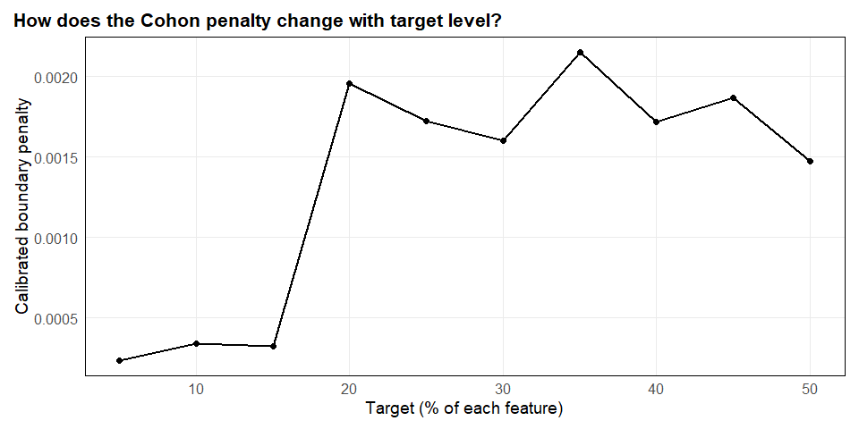

**Observations:**

Calibrated Cohon penalties *generally increase* as conservation targets become more demanding, then tend to level off at higher targets with some fluctuations rather than continuing to rise steadily.

### 5.3 Plot 2

The second plot shows the combined runtime (calibration+solve).

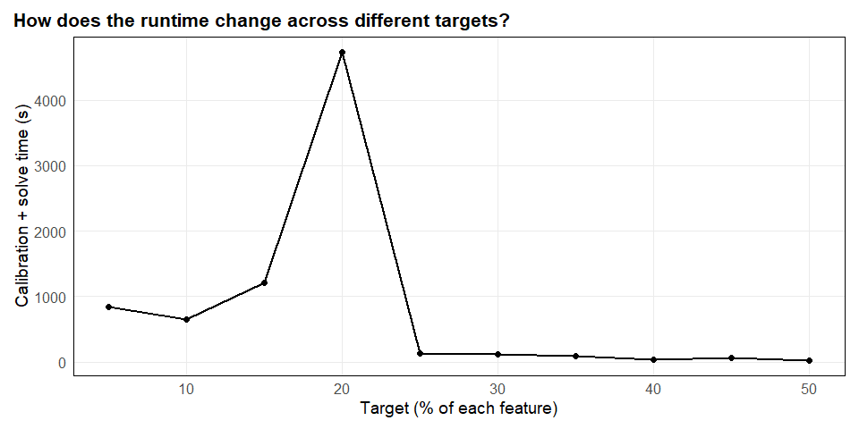

**Observations:**

Calibration runtime *peaks at intermediate targets* and then declines sharply. It then stays consistently low for demanding targets.

# 6. Are target-penalty relationships consistent when feature complexity is reduced?

The previous section varied conservation targets while holding the feature set fixed (100% of features). Here, we assess the sensitivity of Cohon-style calibration to feature set size by repeating the target experiment across predefined feature proportions (**25%, 50%, 75%, and 100%**), with features randomly sampled within each proportion.

To assess whether the observed patterns are robust to execution order, we repeat the analysis using both forward *(Section 6.1)* and reverse target sequences *(Section 6.2)*. In our experiment, we will fix the same subset of features for the increasing target levels.

## 6.1 Forward order (25% → 100%)

### 6.1.1 Table

We summarise the calibrated penalties and associated metrics across targets and feature subset sizes.

```r
cohon_target_results_multi %>%
  dplyr::select(
    scenario, n_features, target,
    feature_prop, n_features_requested, seed,
    cohon_penalty,
    calib_time_sec, solver_time_sec, total_time_sec,
    boundary_length_km, boundary_cost, pu_cost_total, total_cost
  )
```

```
## # A tibble: 40 × 14
##    scenario           n_features target feature_prop n_features_requested   seed
##    <chr>                   <int>  <dbl>        <dbl>                <dbl>  <dbl>
##  1 target_5_feat_6_o…          6   0.05         0.25                    6 200025
##  2 target_5_feat_12_…         12   0.05         0.5                    12 200050
##  3 target_5_feat_18_…         18   0.05         0.75                   18 200075
##  4 target_5_feat_24_…         24   0.05         1                      24 200100
##  5 target_10_feat_6_…          6   0.1          0.25                    6 200025
##  6 target_10_feat_12…         12   0.1          0.5                    12 200050
##  7 target_10_feat_18…         18   0.1          0.75                   18 200075
##  8 target_10_feat_24…         24   0.1          1                      24 200100
##  9 target_15_feat_6_…          6   0.15         0.25                    6 200025
## 10 target_15_feat_12…         12   0.15         0.5                    12 200050
## # ℹ 30 more rows
## # ℹ 8 more variables: cohon_penalty <dbl>, calib_time_sec <dbl>,
## #   solver_time_sec <dbl>, total_time_sec <dbl>, boundary_length_km <dbl>,
## #   boundary_cost <dbl>, pu_cost_total <dbl>, total_cost <dbl>
```

### 6.1.2 Plot 1

The first plot shows how the calibrated penalty varies with targets for each feature proporiton.

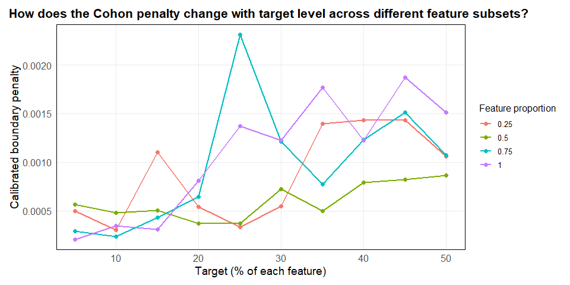

**Observations.**

### 6.1.3 Plot 2

The second plot shows the combined runtime (calibration+solve).

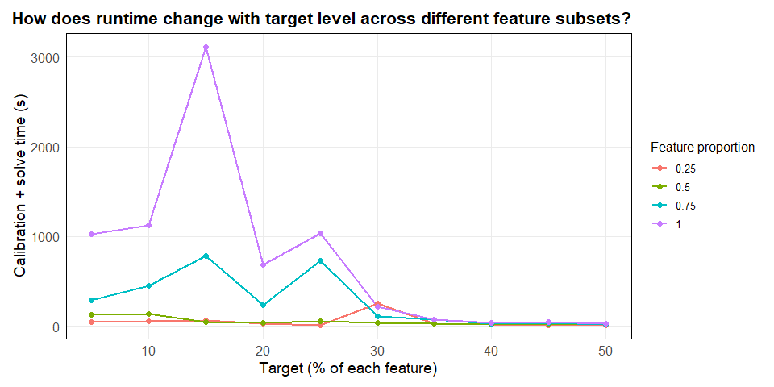

**Observations:**

Runtime *generally increases* with the number of features included, with larger feature sets (75–100%) taking longer to solve than smaller subsets. Across all feature proportions, runtimes tend to be higher at lower to intermediate targets and decrease at higher target levels.

**Notes:** Because the same feature subset is held fixed across all target levels, we cannot assess whether similar patterns would emerge under alternative feature subsets with different spatial configurations using a different seed.

## 6.2 Reverse order (100% → 25%)

We are now interested whether the same patterns emerge if we run the code in reverse order.

### 6.2.1 Table

We summarise the calibrated penalties and associated metrics across targets and feature subset sizes.

```r
cohon_target_results_multi_rev %>%
  dplyr::select(
    order,
    scenario, n_features, target,
    feature_prop, n_features_requested, seed,
    cohon_penalty,
    calib_time_sec, solver_time_sec, total_time_sec,
    boundary_length_km, boundary_cost, pu_cost_total, total_cost
  ) %>%
  dplyr::arrange(target, n_features_requested) %>%
  knitr::kable(
    digits  = 2,
    caption = "Cohon-calibrated penalties across target levels (reverse order only)."
  )
```

Cohon-calibrated penalties across target levels (reverse order only).

| order | scenario | n_features | target | feature_prop | n_features_requested | seed | cohon_penalty | calib_time_sec | solver_time_sec | total_time_sec | boundary_length_km | boundary_cost | pu_cost_total | total_cost |
| --- | --- | --- | --- | --- | --- | --- | --- | --- | --- | --- | --- | --- | --- | --- |
| reverse | target_5_feat_6_of_24_rev | 6 | 0.05 | 0.25 | 6 | 200025 | 0 | 35.61 | 5.30 | 40.91 | 163.89 | 0.08 | 352.76 | 352.84 |
| reverse | target_5_feat_12_of_24_rev | 12 | 0.05 | 0.50 | 12 | 200050 | 0 | 85.45 | 9.17 | 94.62 | 203.63 | 0.06 | 368.53 | 368.59 |
| reverse | target_5_feat_18_of_24_rev | 18 | 0.05 | 0.75 | 18 | 200075 | 0 | 393.36 | 13.36 | 406.72 | 204.23 | 0.08 | 380.48 | 380.56 |
| reverse | target_5_feat_24_of_24_rev | 24 | 0.05 | 1.00 | 24 | 200100 | 0 | 545.89 | 12.22 | 558.11 | 203.40 | 0.05 | 379.65 | 379.69 |
| reverse | target_10_feat_6_of_24_rev | 6 | 0.10 | 0.25 | 6 | 200025 | 0 | 44.11 | 4.75 | 48.86 | 192.46 | 0.06 | 680.71 | 680.77 |
| reverse | target_10_feat_12_of_24_rev | 12 | 0.10 | 0.50 | 12 | 200050 | 0 | 66.83 | 12.94 | 79.77 | 237.79 | 0.15 | 738.75 | 738.90 |
| reverse | target_10_feat_18_of_24_rev | 18 | 0.10 | 0.75 | 18 | 200075 | 0 | 407.06 | 12.40 | 419.46 | 311.53 | 0.07 | 706.76 | 706.83 |
| reverse | target_10_feat_24_of_24_rev | 24 | 0.10 | 1.00 | 24 | 200100 | 0 | 1106.99 | 26.23 | 1133.22 | 309.16 | 0.15 | 753.54 | 753.70 |
| reverse | target_15_feat_6_of_24_rev | 6 | 0.15 | 0.25 | 6 | 200025 | 0 | 50.01 | 11.11 | 61.12 | 231.81 | 0.26 | 1099.77 | 1100.02 |
| reverse | target_15_feat_12_of_24_rev | 12 | 0.15 | 0.50 | 12 | 200050 | 0 | 34.37 | 12.77 | 47.14 | 347.73 | 0.18 | 1054.11 | 1054.29 |
| reverse | target_15_feat_18_of_24_rev | 18 | 0.15 | 0.75 | 18 | 200075 | 0 | 691.54 | 11.73 | 703.27 | 354.62 | 0.13 | 1051.39 | 1051.52 |
| reverse | target_15_feat_24_of_24_rev | 24 | 0.15 | 1.00 | 24 | 200100 | 0 | 2067.66 | 23.14 | 2090.80 | 392.23 | 0.23 | 1109.66 | 1109.89 |
| reverse | target_20_feat_6_of_24_rev | 6 | 0.20 | 0.25 | 6 | 200025 | 0 | 23.86 | 6.35 | 30.21 | 323.44 | 0.20 | 1333.11 | 1333.31 |
| reverse | target_20_feat_12_of_24_rev | 12 | 0.20 | 0.50 | 12 | 200050 | 0 | 30.44 | 11.17 | 41.61 | 372.38 | 0.14 | 1387.16 | 1387.29 |
| reverse | target_20_feat_18_of_24_rev | 18 | 0.20 | 0.75 | 18 | 200075 | 0 | 208.21 | 13.56 | 221.77 | 356.30 | 0.23 | 1418.20 | 1418.43 |
| reverse | target_20_feat_24_of_24_rev | 24 | 0.20 | 1.00 | 24 | 200100 | 0 | 726.31 | 38.05 | 764.36 | 435.90 | 0.35 | 1419.95 | 1420.30 |
| reverse | target_25_feat_6_of_24_rev | 6 | 0.25 | 0.25 | 6 | 200025 | 0 | 8.81 | 4.42 | 13.23 | 384.73 | 0.13 | 1656.97 | 1657.10 |
| reverse | target_25_feat_12_of_24_rev | 12 | 0.25 | 0.50 | 12 | 200050 | 0 | 47.30 | 5.94 | 53.24 | 391.94 | 0.15 | 1724.21 | 1724.36 |
| reverse | target_25_feat_18_of_24_rev | 18 | 0.25 | 0.75 | 18 | 200075 | 0 | 193.94 | 294.59 | 488.53 | 342.72 | 0.79 | 1916.65 | 1917.44 |
| reverse | target_25_feat_24_of_24_rev | 24 | 0.25 | 1.00 | 24 | 200100 | 0 | 218.95 | 47.06 | 266.01 | 453.18 | 0.65 | 1815.75 | 1816.40 |
| reverse | target_30_feat_6_of_24_rev | 6 | 0.30 | 0.25 | 6 | 200025 | 0 | 10.39 | 6.26 | 16.65 | 433.80 | 0.20 | 2005.11 | 2005.30 |
| reverse | target_30_feat_12_of_24_rev | 12 | 0.30 | 0.50 | 12 | 200050 | 0 | 25.99 | 6.72 | 32.71 | 378.87 | 0.28 | 2134.72 | 2134.99 |
| reverse | target_30_feat_18_of_24_rev | 18 | 0.30 | 0.75 | 18 | 200075 | 0 | 99.73 | 12.75 | 112.48 | 422.90 | 0.51 | 2192.01 | 2192.52 |
| reverse | target_30_feat_24_of_24_rev | 24 | 0.30 | 1.00 | 24 | 200100 | 0 | 203.67 | 749.33 | 953.00 | 438.79 | 1.18 | 2239.69 | 2240.87 |
| reverse | target_35_feat_6_of_24_rev | 6 | 0.35 | 0.25 | 6 | 200025 | 0 | 13.30 | 12.49 | 25.79 | 357.84 | 0.50 | 2466.23 | 2466.73 |
| reverse | target_35_feat_12_of_24_rev | 12 | 0.35 | 0.50 | 12 | 200050 | 0 | 15.19 | 9.94 | 25.13 | 422.62 | 0.21 | 2460.65 | 2460.86 |
| reverse | target_35_feat_18_of_24_rev | 18 | 0.35 | 0.75 | 18 | 200075 | 0 | 55.93 | 15.22 | 71.15 | 476.02 | 0.37 | 2528.03 | 2528.40 |
| reverse | target_35_feat_24_of_24_rev | 24 | 0.35 | 1.00 | 24 | 200100 | 0 | 58.37 | 14.71 | 73.08 | 530.39 | 0.94 | 2484.45 | 2485.39 |
| reverse | target_40_feat_6_of_24_rev | 6 | 0.40 | 0.25 | 6 | 200025 | 0 | 10.85 | 10.72 | 21.57 | 371.76 | 0.53 | 2809.50 | 2810.03 |
| reverse | target_40_feat_12_of_24_rev | 12 | 0.40 | 0.50 | 12 | 200050 | 0 | 11.91 | 8.16 | 20.07 | 394.87 | 0.31 | 2846.32 | 2846.63 |
| reverse | target_40_feat_18_of_24_rev | 18 | 0.40 | 0.75 | 18 | 200075 | 0 | 19.08 | 11.81 | 30.89 | 563.56 | 0.69 | 2873.63 | 2874.32 |
| reverse | target_40_feat_24_of_24_rev | 24 | 0.40 | 1.00 | 24 | 200100 | 0 | 21.41 | 29.22 | 50.63 | 566.64 | 0.75 | 2854.51 | 2855.27 |
| reverse | target_45_feat_6_of_24_rev | 6 | 0.45 | 0.25 | 6 | 200025 | 0 | 6.03 | 5.69 | 11.72 | 428.36 | 0.61 | 3128.32 | 3128.93 |
| reverse | target_45_feat_12_of_24_rev | 12 | 0.45 | 0.50 | 12 | 200050 | 0 | 17.89 | 8.77 | 26.66 | 444.74 | 0.36 | 3204.83 | 3205.19 |
| reverse | target_45_feat_18_of_24_rev | 18 | 0.45 | 0.75 | 18 | 200075 | 0 | 14.26 | 28.06 | 42.32 | 552.48 | 0.78 | 3255.06 | 3255.84 |
| reverse | target_45_feat_24_of_24_rev | 24 | 0.45 | 1.00 | 24 | 200100 | 0 | 19.63 | 29.94 | 49.57 | 574.61 | 1.07 | 3219.99 | 3221.06 |
| reverse | target_50_feat_6_of_24_rev | 6 | 0.50 | 0.25 | 6 | 200025 | 0 | 6.83 | 4.97 | 11.80 | 491.37 | 0.52 | 3458.72 | 3459.24 |
| reverse | target_50_feat_12_of_24_rev | 12 | 0.50 | 0.50 | 12 | 200050 | 0 | 9.64 | 6.49 | 16.13 | 500.62 | 0.43 | 3537.01 | 3537.44 |
| reverse | target_50_feat_18_of_24_rev | 18 | 0.50 | 0.75 | 18 | 200075 | 0 | 9.24 | 10.16 | 19.40 | 685.02 | 0.74 | 3638.88 | 3639.61 |
| reverse | target_50_feat_24_of_24_rev | 24 | 0.50 | 1.00 | 24 | 200100 | 0 | 8.48 | 14.79 | 23.27 | 621.42 | 0.91 | 3616.85 | 3617.76 |

### 6.2.2 Plot 1

Here, we plot the reverse plot together with the forward plot side by side to compare if similar trends emerge for calibrated penalties with increasing targets for different feature proportions.

[output not shown]

[output not shown]

**Observations**

### 6.2.3 Plot 2

Here, we plot the reverse and forwards plots showing the runtimes.

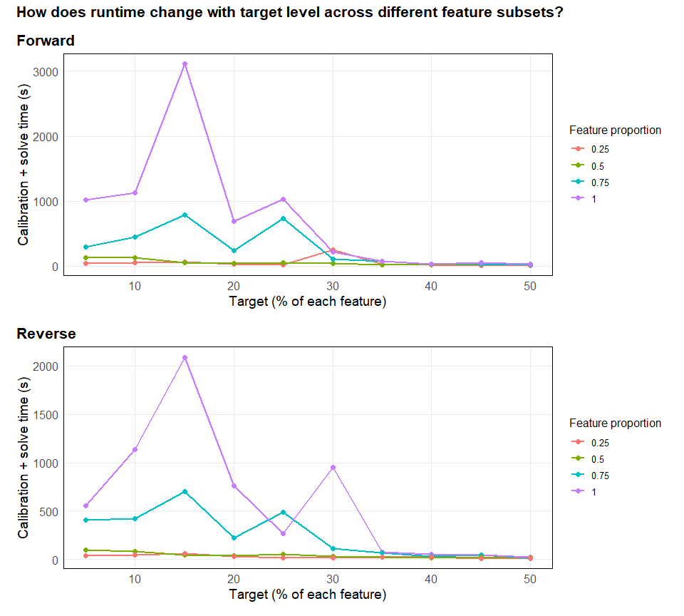

**Observations:**

- The runtime plots are not identical probably due to computer load when running. However, we can see that generally the same patterns emerge. Solvetimes increase from small to intermediate target levels and then dramatically decrease and stabilise as the target levels become even higher.

# 7. How does the Cohon penalty change with the number of features?

Next, we fix the **target** at 30% and vary the **number of features.**

For each feature proportion (20% to 100% in 10% increments), we run multiple replicates (20 replicates) using different random feature subsets. The subsets are chosen at random but with a fixed seed so they are reproducible.

### 7.1.1 Table

We summarise the calibrated penalties and associated metrics across targets and feature subset sizes.

```r
cohon_feature_results %>%
  select(
    scenario, n_features, target,
    cohon_penalty,
    calib_time_sec, solver_time_sec, total_time_sec,
    boundary_length_km, boundary_cost, pu_cost_total, total_cost,
    feature_prop, run, seed
  ) %>%
  arrange(n_features, run) %>%
  knitr::kable(
    digits  = 2,
    caption = paste0(
      "Cohon-calibrated penalties for different numbers of features (target 30%), ",
      "with ", n_reps, " random feature-subset runs per feature count."
    )
  )
```

Cohon-calibrated penalties for different numbers of features (target 30%), with 20 random feature-subset runs per feature count.

| scenario | n_features | target | cohon_penalty | calib_time_sec | solver_time_sec | total_time_sec | boundary_length_km | boundary_cost | pu_cost_total | total_cost | feature_prop | run | seed |
| --- | --- | --- | --- | --- | --- | --- | --- | --- | --- | --- | --- | --- | --- |
| features_4_of_24_run_1 | 4 | 0.3 | 0.00 | 18.09 | 2.80 | 20.89 | 370.61 | 0.12 | 1952.79 | 1952.90 | 0.2 | 1 | 10401 |
| features_4_of_24_run_2 | 4 | 0.3 | 0.00 | 22.73 | 4.25 | 26.98 | 466.76 | 0.07 | 1887.73 | 1887.79 | 0.2 | 2 | 10402 |
| features_4_of_24_run_3 | 4 | 0.3 | 0.00 | 9.81 | 2.92 | 12.73 | 343.57 | 0.12 | 1865.52 | 1865.65 | 0.2 | 3 | 10403 |
| features_4_of_24_run_4 | 4 | 0.3 | 0.00 | 9.42 | 5.46 | 14.88 | 336.75 | 0.16 | 2022.62 | 2022.78 | 0.2 | 4 | 10404 |
| features_4_of_24_run_5 | 4 | 0.3 | 0.00 | 10.75 | 3.25 | 14.00 | 342.55 | 0.19 | 2007.58 | 2007.77 | 0.2 | 5 | 10405 |
| features_4_of_24_run_6 | 4 | 0.3 | 0.00 | 9.85 | 4.24 | 14.09 | 286.20 | 0.50 | 1188.26 | 1188.76 | 0.2 | 6 | 10406 |
| features_4_of_24_run_7 | 4 | 0.3 | 0.00 | 8.78 | 3.24 | 12.02 | 314.45 | 0.30 | 1196.17 | 1196.47 | 0.2 | 7 | 10407 |
| features_4_of_24_run_8 | 4 | 0.3 | 0.00 | 24.63 | 6.64 | 31.27 | 412.05 | 0.10 | 1878.09 | 1878.19 | 0.2 | 8 | 10408 |
| features_4_of_24_run_9 | 4 | 0.3 | 0.00 | 4.52 | 2.75 | 7.27 | 161.95 | 0.20 | 349.08 | 349.27 | 0.2 | 9 | 10409 |
| features_4_of_24_run_10 | 4 | 0.3 | 0.00 | 9.62 | 3.20 | 12.82 | 333.57 | 0.15 | 2022.62 | 2022.77 | 0.2 | 10 | 10410 |
| features_4_of_24_run_11 | 4 | 0.3 | 0.00 | 12.22 | 2.61 | 14.83 | 371.14 | 0.50 | 1592.88 | 1593.38 | 0.2 | 11 | 10411 |
| features_4_of_24_run_12 | 4 | 0.3 | 0.00 | 9.67 | 3.50 | 13.17 | 387.78 | 0.14 | 1884.99 | 1885.14 | 0.2 | 12 | 10412 |
| features_4_of_24_run_13 | 4 | 0.3 | 0.00 | 22.21 | 6.07 | 28.28 | 438.85 | 0.19 | 1869.56 | 1869.75 | 0.2 | 13 | 10413 |
| features_4_of_24_run_14 | 4 | 0.3 | 0.00 | 12.28 | 6.81 | 19.09 | 475.36 | 0.28 | 1994.57 | 1994.85 | 0.2 | 14 | 10414 |
| features_4_of_24_run_15 | 4 | 0.3 | 0.00 | 8.35 | 5.22 | 13.57 | 407.01 | 0.17 | 2017.63 | 2017.79 | 0.2 | 15 | 10415 |
| features_4_of_24_run_16 | 4 | 0.3 | 0.00 | 14.86 | 6.30 | 21.16 | 333.33 | 0.25 | 2009.64 | 2009.89 | 0.2 | 16 | 10416 |
| features_4_of_24_run_17 | 4 | 0.3 | 0.00 | 6.61 | 4.42 | 11.03 | 269.78 | 0.41 | 1189.50 | 1189.91 | 0.2 | 17 | 10417 |
| features_4_of_24_run_18 | 4 | 0.3 | 0.00 | 13.87 | 6.11 | 19.98 | 423.90 | 0.12 | 1956.19 | 1956.31 | 0.2 | 18 | 10418 |
| features_4_of_24_run_19 | 4 | 0.3 | 0.00 | 18.16 | 4.20 | 22.36 | 344.12 | 0.20 | 1979.65 | 1979.85 | 0.2 | 19 | 10419 |
| features_4_of_24_run_20 | 4 | 0.3 | 0.00 | 21.47 | 3.69 | 25.16 | 385.75 | 0.17 | 1989.19 | 1989.36 | 0.2 | 20 | 10420 |
| features_7_of_24_run_1 | 7 | 0.3 | 0.01 | 13.44 | 3.89 | 17.33 | 368.16 | 1.85 | 834.96 | 836.81 | 0.3 | 1 | 10701 |
| features_7_of_24_run_2 | 7 | 0.3 | 0.00 | 9.90 | 9.80 | 19.70 | 394.71 | 0.23 | 2052.56 | 2052.78 | 0.3 | 2 | 10702 |
| features_7_of_24_run_3 | 7 | 0.3 | 0.00 | 13.03 | 4.85 | 17.88 | 419.15 | 0.11 | 2038.20 | 2038.30 | 0.3 | 3 | 10703 |
| features_7_of_24_run_4 | 7 | 0.3 | 0.00 | 28.44 | 7.66 | 36.10 | 532.86 | 0.19 | 1985.51 | 1985.70 | 0.3 | 4 | 10704 |
| features_7_of_24_run_5 | 7 | 0.3 | 0.00 | 7.20 | 9.53 | 16.73 | 419.16 | 0.21 | 2015.65 | 2015.86 | 0.3 | 5 | 10705 |
| features_7_of_24_run_6 | 7 | 0.3 | 0.00 | 117.21 | 4.14 | 121.35 | 507.24 | 0.21 | 1882.14 | 1882.35 | 0.3 | 6 | 10706 |
| features_7_of_24_run_7 | 7 | 0.3 | 0.00 | 88.38 | 9.51 | 97.89 | 519.23 | 0.20 | 1989.50 | 1989.70 | 0.3 | 7 | 10707 |
| features_7_of_24_run_8 | 7 | 0.3 | 0.00 | 45.01 | 5.82 | 50.83 | 338.90 | 0.19 | 1928.47 | 1928.66 | 0.3 | 8 | 10708 |
| features_7_of_24_run_9 | 7 | 0.3 | 0.00 | 14.41 | 3.53 | 17.94 | 411.67 | 0.17 | 1966.16 | 1966.33 | 0.3 | 9 | 10709 |
| features_7_of_24_run_10 | 7 | 0.3 | 0.00 | 23.58 | 8.46 | 32.04 | 400.55 | 0.25 | 2015.77 | 2016.02 | 0.3 | 10 | 10710 |

[output cut: 150 more lines]

### 7.1.2 Plot 1

The first plot shows how the calibrated boundary penalty changes as the number of features increase, while looking at different random subsets.

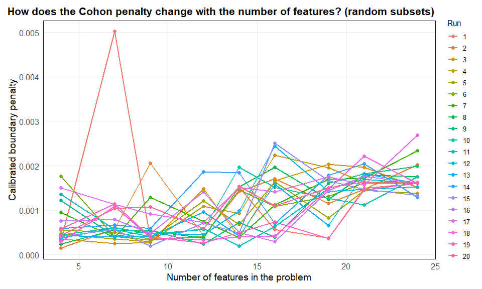

**Observations**:

- There is not a strict general pattern for the relationship between the calibrated boundary penalty and increasing number of features. However, it can be said that there is slight **general increase** with the calibrated penalty as the number of features increase.

### 7.1.3 Plot 2

The plot here shows the relationship between runtimes and increasing number of features.

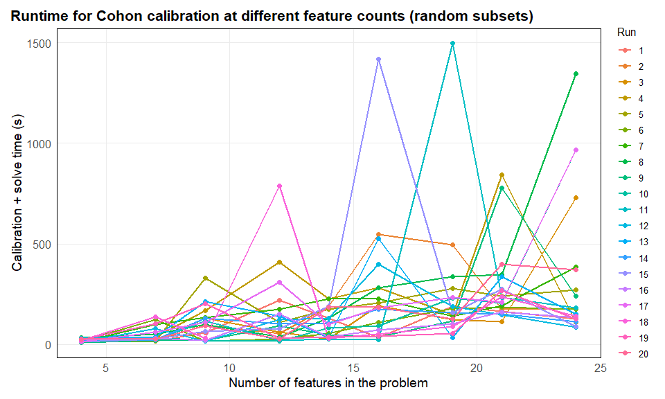

**Observations:**

- Due to the outlier, which shows a very long runtime, it is difficult to look at the overall pattern. Nonetheless, it can be said that the calibration time *generally slighlty increases* with an increase in the number of features.

**Notes:**

To check whether evaluation order affects results, we repeat the same experiment but iterate through feature proportions in reverse order (100% down to 20%). In principle, results should be consistent given identical random seeds.

### 7.2.1 Table

We summarise the calibrated penalties and associated metrics across targets and feature subset sizes.

```r
cohon_feature_results_rev %>%
  select(
    scenario, n_features, target,
    cohon_penalty,
    calib_time_sec, solver_time_sec, total_time_sec,
    boundary_length_km, pu_cost_total, total_cost,
    feature_prop, run, seed, order
  ) %>%
  arrange(n_features, run) %>%
  knitr::kable(
    digits  = 2,
    caption = paste0(
      "REVERSE order: Cohon-calibrated penalties for different numbers of features (target 30%), ",
      "with ", n_reps, " random feature-subset runs per feature count."
    )
  )
```

REVERSE order: Cohon-calibrated penalties for different numbers of features (target 30%), with 20 random feature-subset runs per feature count.

| scenario | n_features | target | cohon_penalty | calib_time_sec | solver_time_sec | total_time_sec | boundary_length_km | pu_cost_total | total_cost | feature_prop | run | seed | order |
| --- | --- | --- | --- | --- | --- | --- | --- | --- | --- | --- | --- | --- | --- |
| features_4_of_24_run_1_rev | 4 | 0.3 | 0.00 | 17.47 | 2.40 | 19.87 | 370.61 | 1952.79 | 1952.90 | 0.2 | 1 | 10401 | reverse |
| features_4_of_24_run_2_rev | 4 | 0.3 | 0.00 | 21.81 | 3.97 | 25.78 | 466.76 | 1887.73 | 1887.79 | 0.2 | 2 | 10402 | reverse |
| features_4_of_24_run_3_rev | 4 | 0.3 | 0.00 | 9.38 | 2.80 | 12.18 | 343.57 | 1865.52 | 1865.65 | 0.2 | 3 | 10403 | reverse |
| features_4_of_24_run_4_rev | 4 | 0.3 | 0.00 | 9.26 | 5.53 | 14.79 | 336.75 | 2022.62 | 2022.78 | 0.2 | 4 | 10404 | reverse |
| features_4_of_24_run_5_rev | 4 | 0.3 | 0.00 | 10.73 | 3.30 | 14.03 | 342.55 | 2007.58 | 2007.77 | 0.2 | 5 | 10405 | reverse |
| features_4_of_24_run_6_rev | 4 | 0.3 | 0.00 | 9.58 | 5.10 | 14.68 | 287.60 | 1186.35 | 1186.86 | 0.2 | 6 | 10406 | reverse |
| features_4_of_24_run_7_rev | 4 | 0.3 | 0.00 | 8.58 | 3.19 | 11.77 | 314.45 | 1196.17 | 1196.47 | 0.2 | 7 | 10407 | reverse |
| features_4_of_24_run_8_rev | 4 | 0.3 | 0.00 | 23.73 | 5.90 | 29.63 | 332.77 | 1905.20 | 1905.52 | 0.2 | 8 | 10408 | reverse |
| features_4_of_24_run_9_rev | 4 | 0.3 | 0.00 | 4.39 | 2.50 | 6.89 | 161.95 | 349.08 | 349.27 | 0.2 | 9 | 10409 | reverse |
| features_4_of_24_run_10_rev | 4 | 0.3 | 0.00 | 9.94 | 2.92 | 12.86 | 333.57 | 2022.62 | 2022.77 | 0.2 | 10 | 10410 | reverse |
| features_4_of_24_run_11_rev | 4 | 0.3 | 0.00 | 12.36 | 2.60 | 14.96 | 371.14 | 1592.88 | 1593.38 | 0.2 | 11 | 10411 | reverse |
| features_4_of_24_run_12_rev | 4 | 0.3 | 0.00 | 9.18 | 3.53 | 12.71 | 387.78 | 1884.99 | 1885.14 | 0.2 | 12 | 10412 | reverse |
| features_4_of_24_run_13_rev | 4 | 0.3 | 0.00 | 21.97 | 6.07 | 28.04 | 438.85 | 1869.56 | 1869.75 | 0.2 | 13 | 10413 | reverse |
| features_4_of_24_run_14_rev | 4 | 0.3 | 0.00 | 12.33 | 6.45 | 18.78 | 501.38 | 1991.08 | 1991.37 | 0.2 | 14 | 10414 | reverse |
| features_4_of_24_run_15_rev | 4 | 0.3 | 0.00 | 8.44 | 4.34 | 12.78 | 411.37 | 2022.17 | 2022.34 | 0.2 | 15 | 10415 | reverse |
| features_4_of_24_run_16_rev | 4 | 0.3 | 0.00 | 14.80 | 6.33 | 21.13 | 333.33 | 2009.64 | 2009.89 | 0.2 | 16 | 10416 | reverse |
| features_4_of_24_run_17_rev | 4 | 0.3 | 0.00 | 6.08 | 4.59 | 10.67 | 269.78 | 1189.50 | 1189.91 | 0.2 | 17 | 10417 | reverse |
| features_4_of_24_run_18_rev | 4 | 0.3 | 0.00 | 14.22 | 6.03 | 20.25 | 423.90 | 1956.19 | 1956.31 | 0.2 | 18 | 10418 | reverse |
| features_4_of_24_run_19_rev | 4 | 0.3 | 0.00 | 18.80 | 3.92 | 22.72 | 344.12 | 1979.65 | 1979.85 | 0.2 | 19 | 10419 | reverse |
| features_4_of_24_run_20_rev | 4 | 0.3 | 0.00 | 21.91 | 3.57 | 25.48 | 385.75 | 1989.19 | 1989.36 | 0.2 | 20 | 10420 | reverse |
| features_7_of_24_run_1_rev | 7 | 0.3 | 0.01 | 13.31 | 4.05 | 17.36 | 368.16 | 834.96 | 836.81 | 0.3 | 1 | 10701 | reverse |
| features_7_of_24_run_2_rev | 7 | 0.3 | 0.00 | 10.22 | 10.32 | 20.54 | 394.71 | 2052.56 | 2052.78 | 0.3 | 2 | 10702 | reverse |
| features_7_of_24_run_3_rev | 7 | 0.3 | 0.00 | 13.16 | 3.76 | 16.92 | 457.35 | 2014.07 | 2014.19 | 0.3 | 3 | 10703 | reverse |
| features_7_of_24_run_4_rev | 7 | 0.3 | 0.00 | 27.94 | 8.15 | 36.09 | 487.82 | 2002.37 | 2002.54 | 0.3 | 4 | 10704 | reverse |
| features_7_of_24_run_5_rev | 7 | 0.3 | 0.00 | 7.11 | 9.15 | 16.26 | 419.16 | 2015.65 | 2015.86 | 0.3 | 5 | 10705 | reverse |
| features_7_of_24_run_6_rev | 7 | 0.3 | 0.00 | 48.05 | 4.78 | 52.83 | 523.41 | 1874.92 | 1875.13 | 0.3 | 6 | 10706 | reverse |
| features_7_of_24_run_7_rev | 7 | 0.3 | 0.00 | 89.84 | 9.73 | 99.57 | 519.23 | 1989.50 | 1989.70 | 0.3 | 7 | 10707 | reverse |
| features_7_of_24_run_8_rev | 7 | 0.3 | 0.00 | 45.15 | 5.86 | 51.01 | 338.90 | 1928.47 | 1928.66 | 0.3 | 8 | 10708 | reverse |
| features_7_of_24_run_9_rev | 7 | 0.3 | 0.00 | 14.02 | 3.77 | 17.79 | 411.67 | 1966.16 | 1966.33 | 0.3 | 9 | 10709 | reverse |
| features_7_of_24_run_10_rev | 7 | 0.3 | 0.00 | 24.19 | 8.39 | 32.58 | 400.55 | 2015.77 | 2016.02 | 0.3 | 10 | 10710 | reverse |

[output cut: 150 more lines]

### 7.2.2 Plot 1

Here, we plot both reverse and forward orders side by side to show whether we obtain the same trend for the relationship between calibrated boundary penalty and the increasing number of features.

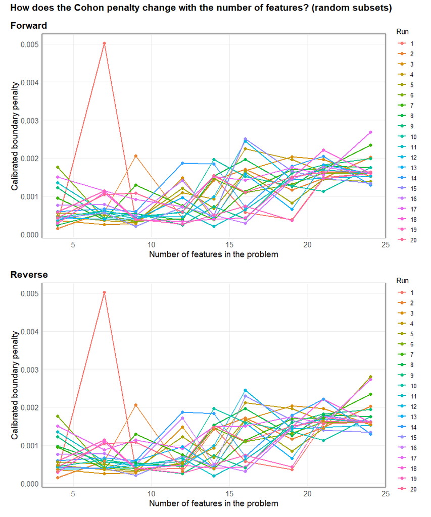

**Observations:**

### 7.2.3 Plot 2

Here, we plot both reverse and forward orders side by side to show whether we obtain the same trend for the relationship between the runtimes and the increasing number of features.

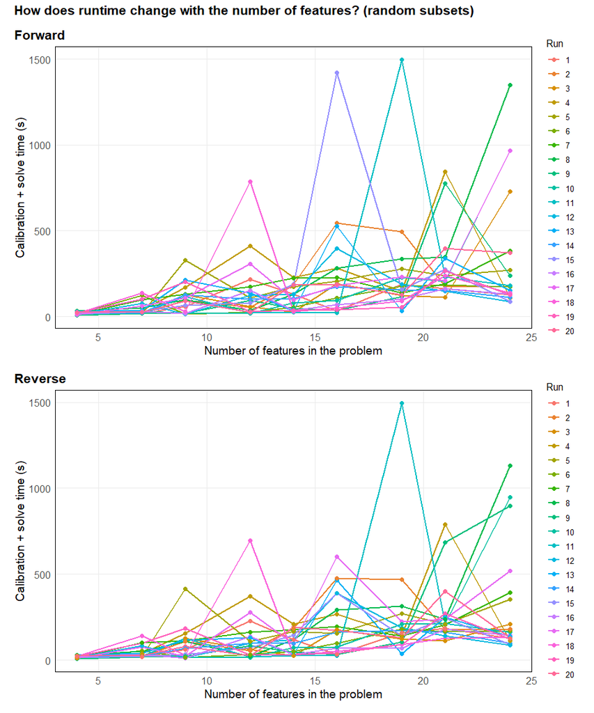

**Observations:**

- The runtime for both forward and reverse orders are generally the same, but not completely identical.

# 8. Take home messages

1. Calibrated boundary penalties can change with conservation targets.
2. Penalties are sensitive to feature richness and composition because calibration responds to spatial structure.
3. Calibration introduces computational overhead that should be considered in applied planning workflows.